# Title: **Identifications and Solutions for the Aging Workforce in Malaysia**

### **Group Members:**

| Names | Matric.ID |
| --- | --- |
| Wong Jia Hui | S2192852 |
| Danial Mirza Bin Madrawi | 22062607 |
| Low Boon Kiat | 17138399 |
| Hongsheng Jie | 22064728 |
| Yuejing Huang | S2158553 |

### **Introduction**

According to a report from United Nations (UN) in 2015, the world is moving towards an aging population. The number of elderly population is estimated to reach 1.4 billion by 2030 and 2.1 billion by 2050. The ageing of the world’s population is the result of decline in birth rate and increased life expectancy due to better health facilities which have changed the demographic trends across the global. One of the major impacts faced by the organisation and governments will be aging workforce. Organisation and governments are required to make adjustment on the existing infrastructure and policies to meet the needs of aging workforce trends.

This project focuses on identifying the trends of aging workforce in Malaysia and discusses how Malaysia could address the challenges arise from aging workforce based on the collected time-series data starting from year 1982 to year 2021. A predictive model will also be proposed for predicting the unemployment rate and growth rate of aging workforce in Malaysia.

### **Objective**

The objectives of this project are:-

1. To identify trends of aging workforce in Malaysia.
2. To propose mitigation measures to address aging workforce challenges.
3. To develop a predictive model for predicting unemployment rate and growth rate of aging workforce.

### **Methodology**

1. Define Problem: The problem from this project is defined. To prove the labor force of Malaysia is aging using Population Dataset.
2. Data Procurement: The data sources were obtained from Ministry of Statistics Malaysia website.
3. Data Understanding: Finding the existence of null value, the definition of each columns.
4. Data Preparation: Concatinating multiple sources into one, change the intital columns’ names into more understandatble names. Separate labour force by age groups and genders. Convert age columns into numeric columns
5. Data Cleaning: Null values were replaced with value using Linear Model. The data now void from any null value.
6. Exploratory Data Analysis: Using the data, descriptive and visual analysis of the data was done to uncover patterns, trends, relationships, and insights. You may also use statistical tests and hypothesis testing to validate your findings.
7. Modeling: This is where you apply various machine learning or statistical techniques to build predictive or explanatory models based on the data. You should also evaluate the performance and accuracy of your models using appropriate metrics and methods.
8. Results and Discussion: This is where you communicate your findings and recommendations to the stakeholders or audience. You should also discuss the limitations and assumptions of your analysis, as well as any future steps or improvements that can be made.

### **Data Understanding**

During Data Understanding phase, raw data is identified, collected and analyzed for the usage of this project

- Under category of Malaysia Economic Statistics - Time Series 2019
  - No.19 - Population
- Under category of Labour Force Survery (LFS) Time Series Statistics by State, 1982 - 2021
  - No.1 - Employed persons by age group, Malaysia/states
  - No.9 - Labour force by age group, Malaysia/states
  - No.18 - Principal statistics of the labour force by sex, Malaysia

Since multiple raw datasets are acquired, data extraction and data integration is required to process the raw datasets into a clean dataset for data analysis and to train the predictive model.

**2. Data Description**

The description of each raw data sets collected is shown in the table below:-

[output not shown]

**3. Data Quality**

The comments on the data quality of those collected raw data sets are shown below:-

[output not shown]

Based on the comments, data cleaning is required to fill in the missing values. The process of data cleaning will be discussed in later stage.

### **Data Preparation**

**1. Data Extraction and Selection**

```r
# Extract data from raw .xlsx file and create a new dataframe
library(xlsx)
population_df <- read.xlsx("./Data/no19.xlsx", sheetIndex = 1, rowIndex = 6:91, colIndex = 1:7)
lifeexp_df <- read.xlsx("./Data/no19.xlsx", sheetIndex = 3, rowIndex = 12:66, colIndex = 1:11)
birthrate_df <- read.xlsx("./Data/no19.xlsx", sheetIndex = 2, rowIndex = 13:117, colIndex = 1:9)
labour_df <- read.xlsx("./Data/no9.xlsx", sheetIndex = 1, rowIndex = 5:43, colIndex = 2:13)
employ_df <- read.xlsx("./Data/no1.xlsx", sheetIndex = 1, rowIndex = 5:43, colIndex = 2:13)
malewf_df <- read.xlsx("./Data/no18.xlsx", sheetIndex = 1, rowIndex = 8:46, colIndex = 2:9)
femalewf_df <- read.xlsx("./Data/no18.xlsx", sheetIndex = 2, rowIndex = 8:46, colIndex = 2:9)

# Rename column names
colnames(population_df) <- c("year", "total", "", "age0-14", "age15-64", "age65+", "avg_apgr")
colnames(lifeexp_df) <- c("year", "m_life", "f_life", "bm_life", "bf_life", "cm_life", "cf_life", "im_life", "if_life", "om_life", "of_life")
colnames(birthrate_df) <- c("year", "cr_naturalincrease", "crude_br", "crude_dr", "total_fr", "neonatal_mr", "infant_mr", "toddler_mr", "maternal_mr")
colnames(labour_df) <- c("year", "total", "age15-19", "age20-24", "age25-29", "age30-34", "age35-39", "age40-44", "age45-49", "age50-54", "age55-59", "age60-64")
colnames(employ_df) <- c("year", "total", "age15-19", "age20-24", "age25-29", "age30-34", "age35-39", "age40-44", "age45-49", "age50-54", "age55-59", "age60-64")
colnames(malewf_df) <-c("year", "m_lf", "m_employed", "m_work<30hrs", "m_unemployed", "m_outside_lf", "participationrate_lf", "unemployment_rate")
colnames(femalewf_df) <-c("year", "f_lf", "f_employed", "f_work<30hrs", "f_unemployed", "f_outside_lf", "participationrate_lf", "unemployment_rate")

# Add new rows with empty data to represent missing year and remove data that do not fall within the year of 1982 - 2021
new_row1 <- population_df[1:2,]
new_row1[] <- NA
population_df <- rbind(population_df, new_row1)
population_df <- population_df[-1:-47,]
population_df$year <- c(1982:2021)

new_row1 <- lifeexp_df[1:2,]
new_row1[] <- NA
lifeexp_df <- rbind(lifeexp_df, new_row1)
lifeexp_df <- lifeexp_df[-1:-16,]
lifeexp_df$year <- c(1982:2021)

new_row1 <- birthrate_df[1:2,]
new_row1[] <- NA
birthrate_df <- rbind(birthrate_df, new_row1)
birthrate_df <- birthrate_df[-1:-66,]
birthrate_df$year <- c(1982:2021)

library(tidyverse)
labour_df <- labour_df %>% add_row(year = 1991, `age15-19` = NA, `age20-24` = NA, `age25-29` = NA, `age30-34` = NA, `age35-39` = NA, `age40-44` = NA, `age45-49` = NA, `age50-54` = NA, `age55-59` = NA, `age60-64` = NA, .before = 10)
labour_df <- labour_df %>% add_row(year = 1994, `age15-19` = NA, `age20-24` = NA, `age25-29` = NA, `age30-34` = NA, `age35-39` = NA, `age40-44` = NA, `age45-49` = NA, `age50-54` = NA, `age55-59` = NA, `age60-64` = NA, .before = 13)

employ_df <- employ_df %>% add_row(year = 1991, `age15-19` = NA, `age20-24` = NA, `age25-29` = NA, `age30-34` = NA, `age35-39` = NA, `age40-44` = NA, `age45-49` = NA, `age50-54` = NA, `age55-59` = NA, `age60-64` = NA, .before = 10)
employ_df <- employ_df %>% add_row(year = 1994, `age15-19` = NA, `age20-24` = NA, `age25-29` = NA, `age30-34` = NA, `age35-39` = NA, `age40-44` = NA, `age45-49` = NA, `age50-54` = NA, `age55-59` = NA, `age60-64` = NA, .before = 13)

malewf_df <- malewf_df %>% add_row(year = 1991, m_lf = NA, m_employed = NA, `m_work<30hrs`= NA, m_unemployed = NA, m_outside_lf = NA, participationrate_lf = NA, unemployment_rate = NA, .before = 10)
malewf_df <- malewf_df %>% add_row(year = 1991, m_lf = NA, m_employed = NA, `m_work<30hrs`= NA, m_unemployed = NA, m_outside_lf = NA, participationrate_lf = NA, unemployment_rate = NA, .before = 13)

femalewf_df <- femalewf_df %>% add_row(year = 1991, f_lf = NA, f_employed = NA, `f_work<30hrs`= NA, f_unemployed = NA, f_outside_lf = NA, participationrate_lf = NA, unemployment_rate = NA, .before = 10)
femalewf_df <- femalewf_df %>% add_row(year = 1991, f_lf = NA, f_employed = NA, `f_work<30hrs`= NA, f_unemployed = NA, f_outside_lf = NA, participationrate_lf = NA, unemployment_rate = NA, .before = 13)

# Filter out the required data for data merging/integration to create a brand new dataset for our project usage
labour_df$`age15-59` <- rowSums(labour_df[,3:11])
employ_df$`age15-59` <- rowSums(employ_df[,3:11])
df <- data.frame(population_df$year, malewf_df$m_lf, femalewf_df$f_lf, malewf_df$m_employed, femalewf_df$f_employed, population_df$`age0-14`, labour_df$`age15-59`, labour_df$`age60-64`, employ_df$`age15-59`, employ_df$`age60-64`, population_df$`age65+`, lifeexp_df$m_life, lifeexp_df$f_life, birthrate_df$crude_br)
colnames(df) <- c('year', 'm_lf', 'f_lf', 'm_employed', 'f_employed', 'age0-14', 'age15-59_lf', 'age60-64_lf', 'age15-59_employ', 'age60-64_employ', 'age65+', 'm_life', 'f_life', 'br')

# Check for data structure and standardize it (if required)
str(df)
```

```
## 'data.frame':    40 obs. of  14 variables:
##  $ year           : int  1982 1983 1984 1985 1986 1987 1988 1989 1990 1991 ...
##  $ m_lf           : num  3562 3693 3832 3897 4038 ...
##  $ f_lf           : num  1869 1979 2030 2094 2184 ...
##  $ m_employed     : num  3465 3570 3663 3700 3754 ...
##  $ f_employed     : num  1784 1886 1904 1953 2007 ...
##  $ age0-14        : chr  "5723.7" "5818.8" "5933.9" "6081.2" ...
##  $ age15-59_lf    : num  5291 5516 5712 5847 6076 ...
##  $ age60-64_lf    : num  140 156 151 143 146 ...
##  $ age15-59_employ: num  5110 5304 5419 5514 5618 ...
##  $ age60-64_employ: num  139 153 147 139 142 ...
##  $ age65+         : chr  "527" "543.3" "559.3" "574.2" ...
##  $ m_life         : num  67.1 67.1 67.2 67.7 68.2 68.5 68.7 68.8 68.9 69.2 ...
##  $ f_life         : num  71.3 71.6 71.8 72.4 72.6 72.9 73.1 73.3 73.5 73.4 ...
##  $ br             : chr  "31" "30.2" "31" "31.5" ...
```

```r
df[, c("age0-14", "age65+", "br")] <- lapply(df[, c("age0-14", "age65+", "br")], as.numeric)
str(df)
```

```
## 'data.frame':    40 obs. of  14 variables:
##  $ year           : int  1982 1983 1984 1985 1986 1987 1988 1989 1990 1991 ...
##  $ m_lf           : num  3562 3693 3832 3897 4038 ...
##  $ f_lf           : num  1869 1979 2030 2094 2184 ...
##  $ m_employed     : num  3465 3570 3663 3700 3754 ...
##  $ f_employed     : num  1784 1886 1904 1953 2007 ...
##  $ age0-14        : num  5724 5819 5934 6081 6224 ...
##  $ age15-59_lf    : num  5291 5516 5712 5847 6076 ...
##  $ age60-64_lf    : num  140 156 151 143 146 ...
##  $ age15-59_employ: num  5110 5304 5419 5514 5618 ...
##  $ age60-64_employ: num  139 153 147 139 142 ...
##  $ age65+         : num  527 543 559 574 591 ...
##  $ m_life         : num  67.1 67.1 67.2 67.7 68.2 68.5 68.7 68.8 68.9 69.2 ...
##  $ f_life         : num  71.3 71.6 71.8 72.4 72.6 72.9 73.1 73.3 73.5 73.4 ...
##  $ br             : num  31 30.2 31 31.5 30.6 29.3 29.7 26.8 27.9 27.6 ...
```

```r
df[,2:14] <- round(df[,2:14], 2)
```

After the data wrangling process, a **dataset, df** is created and ready for data cleaning process.

The data description is explained in the table below:-

| Column Name | Description |
| --- | --- |
| year | Year for collected data |
| m_lf | Male labour force (in thousand) |
| f_lf | Female labour force (in thousand) |
| m_employed | Male employed person (in thousand) |
| f_employed | Female employed person (in thousand) |
| age0-14 | Population under the age of 0 - 14 (in thousand) |
| age15-59_lf | Labour force under the agoe of 15 - 59 (in thousand) |
| age60-64_lf | Labour force under the age of 60 - 64 (in thousand) |
| age15-59_employ | Employed person under the age of 15 - 59 (in thousand) |
| age60-64_employ | Employed person under the age of 60 -64 (in thousand) |
| age65+ | Population above the age of 65 |
| m_life | Male life expectancy |
| f_life | Female life expectancy |
| br | Birth rate (in %) |

### **Data Cleaning**

```r
clean_df <- df

# Model-based imputation for missing data
i<-1
j<-1
for (i in 1:nrow(clean_df)){
     for (j in 1:ncol(clean_df)){
         if (is.na(clean_df[i,j])==TRUE){
             fit_data<-clean_df[(i-2):(i+2),c(2,j)]
             model<-lm(unlist(clean_df[(i-2):(i+2),j])~unlist(clean_df[(i-2):(i+2),"year"]),fit_data,na.action=na.exclude)
             new_data<-data.frame(clean_df[(i-2):(i+2),2])
             predicted_data<-predict(model,new_data)
             clean_df[i,j]<-predicted_data[3]
         }else if(i==40){
             break
         }else{
             i=i+1
             j=j+1
         }
     }
}

# Round to 1 decimal place
clean_df[,2:14] <- round(clean_df[,2:14],1)
clean_df
```

```
##    year   m_lf   f_lf m_employed f_employed age0-14 age15-59_lf age60-64_lf
## 1  1982 3562.3 1869.1     3465.3     1783.7  5723.7      5290.9       140.5
## 2  1983 3693.1 1978.8     3570.4     1886.5  5818.8      5515.9       155.9
## 3  1984 3832.2 2030.3     3662.6     1904.1  5933.9      5711.6       151.0
## 4  1985 3896.7 2093.5     3700.5     1952.8  6081.2      5847.3       142.9
## 5  1986 4037.7 2184.3     3753.5     2006.6  6223.5      6075.5       146.5
## 6  1987 4151.3 2305.5     3868.0     2115.9  6370.0      6301.8       155.1
## 7  1988 4268.7 2368.4     3984.0     2173.2  6512.0      6478.5       158.6
## 8  1989 4389.1 2390.3     4155.3     2235.5  6650.0      6624.8       154.6
## 9  1990 4489.8 2510.3     4310.7     2374.3  6775.0      6833.0       167.1
## 10 1991 4659.7 2540.0     4468.5     2408.2  6899.9      7036.0       163.6
## 11 1992 4716.5 2602.5     4554.2     2493.6  7038.6      7147.9       171.1
## 12 1993 5043.3 2656.9     4853.8     2529.6  7192.0      7538.5       161.6
## 13 1994 5154.2 2727.9     4994.7     2624.1  7329.2      7706.3       175.7
## 14 1995 5203.1 2690.0     5056.6     2588.4  7453.3      7717.7       175.4
```

[output cut: 67 more lines]

```r
write.csv(clean_df, file="clean-data.csv",row.names=FALSE)
```

### **Exploratory Data Analysis (EDA)**

```r
# Load libraries
library("dplyr")
library("ggplot2")
library("reshape2")
# Load files
data = read.csv("./Data/clean-data.csv")
# Create DataFrame
df = data.frame(data)
# Check datatypes of DataFrame columns
str(df)
```

```
## 'data.frame':    40 obs. of  14 variables:
##  $ year           : int  1982 1983 1984 1985 1986 1987 1988 1989 1990 1991 ...
##  $ m_lf           : num  3562 3693 3832 3897 4038 ...
##  $ f_lf           : num  1869 1979 2030 2094 2184 ...
##  $ m_employed     : num  3465 3570 3663 3700 3754 ...
##  $ f_employed     : num  1784 1886 1904 1953 2007 ...
##  $ age0.14        : num  5724 5819 5934 6081 6224 ...
##  $ age15.59_lf    : num  5291 5516 5712 5847 6076 ...
##  $ age60.64_lf    : num  140 156 151 143 146 ...
##  $ age15.59_employ: num  5110 5304 5419 5514 5618 ...
##  $ age60.64_employ: num  139 153 147 139 142 ...
##  $ age65.         : num  527 543 559 574 591 ...
##  $ m_life         : num  67.1 67.1 67.2 67.7 68.2 68.5 68.7 68.8 68.9 69.2 ...
##  $ f_life         : num  71.3 71.6 71.8 72.4 72.6 72.9 73.1 73.3 73.5 73.4 ...
##  $ br             : num  31 30.2 31 31.5 30.6 29.3 29.7 26.8 27.9 27.6 ...
```

```r
# Summarize DataFame
summary(df)
```

```
##       year           m_lf           f_lf        m_employed     f_employed
##  Min.   :1982   Min.   :3562   Min.   :1869   Min.   :3465   Min.   :1784
##  1st Qu.:1992   1st Qu.:4702   1st Qu.:2587   1st Qu.:4533   1st Qu.:2472
##  Median :2002   Median :6310   Median :3482   Median :6099   Median :3351
##  Mean   :2002   Mean   :6464   Mean   :3698   Mean   :6236   Mean   :3548
##  3rd Qu.:2011   3rd Qu.:8234   3rd Qu.:4627   3rd Qu.:7993   3rd Qu.:4475
##  Max.   :2021   Max.   :9629   Max.   :6168   Max.   :9202   Max.   :5874
##     age0.14      age15.59_lf     age60.64_lf    age15.59_employ age60.64_employ
##  Min.   :5724   Min.   : 5291   Min.   :140.5   Min.   : 5110   Min.   :138.9
##  1st Qu.:7004   1st Qu.: 7120   1st Qu.:166.2   1st Qu.: 6839   1st Qu.:163.0
##  Median :7717   Median : 9574   Median :219.6   Median : 9235   Median :216.2
##  Mean   :7385   Mean   : 9914   Mean   :248.4   Mean   : 9540   Mean   :244.5
##  3rd Qu.:7871   3rd Qu.:12540   3rd Qu.:321.3   3rd Qu.:12151   3rd Qu.:317.3
##  Max.   :8098   Max.   :15335   Max.   :465.0   Max.   :14687   Max.   :448.6
##      age65.         m_life          f_life            br
##  Min.   : 527   Min.   :67.10   Min.   :71.30   Min.   :14.30
##  1st Qu.: 699   1st Qu.:69.35   1st Qu.:73.72   1st Qu.:17.50
##  Median :1001   Median :70.65   Median :75.15   Median :20.55
##  Mean   :1159   Mean   :70.38   Mean   :75.04   Mean   :22.17
##  3rd Qu.:1511   3rd Qu.:72.10   3rd Qu.:76.83   3rd Qu.:27.60
##  Max.   :2369   Max.   :72.50   Max.   :77.70   Max.   :31.50
```

```r
# Check columns' names
colnames(df)
```

```
##  [1] "year"            "m_lf"            "f_lf"            "m_employed"
##  [5] "f_employed"      "age0.14"         "age15.59_lf"     "age60.64_lf"
##  [9] "age15.59_employ" "age60.64_employ" "age65."          "m_life"
## [13] "f_life"          "br"
```

```r
# Change columns' names
colnames(df) = c("Year",
                 "Labour_Force_Male_thousands",
                 "Labour_Force_Female_thousands",
                 "Employed_Male_thousands",
                 "Employed_Female_thousands",
                 "Age_0_to_14_thousands",
                 "Labour_Force_Age_15_to_59_thousands",
                 "Labour_Force_Age_60_to_64_thousands",
                 "Employed_Age_15_to_59_thousands",
                 "Employed_Age_60_to_64_thousands",
                 "Age_above_65",
                 "Life_Expectancy_Male",
                 "Life_Expectancy_Female",
                 "Birth_Rate_percentage")
# Total Labour Force
df$Labour_Force_Male_thousands+ df$Labour_Force_Female_thousands
```

```
##  [1]  5431.4  5671.9  5862.5  5990.2  6222.0  6456.8  6637.1  6779.4  7000.1
## [10]  7199.7  7319.0  7700.2  7882.1  7893.1  8616.0  8784.0  8883.6  9151.5
## [19]  9556.1  9699.4  9886.2 10239.5 10346.2 10413.4 10628.9 10889.5 11028.1
## [28] 11315.3 12303.9 12740.7 13221.6 13980.5 14263.6 14517.9 14667.8 14980.0
## [37] 15280.3 15581.6 15667.8 15797.2
```

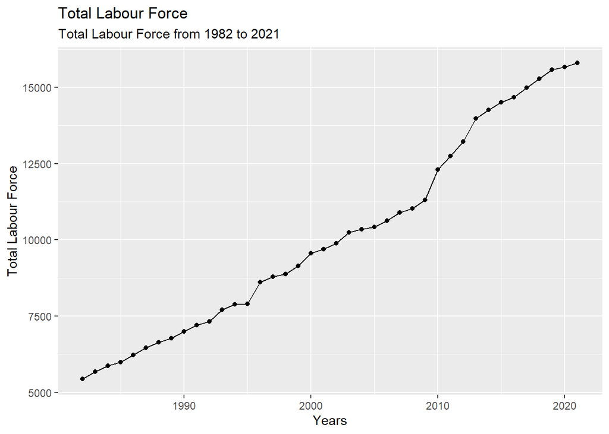

```r
# Total Labour Force by Year
ggplot(data = df["Labour_Force_Male_thousands"] + df["Labour_Force_Female_thousands"],
       mapping = aes(x = as.integer(df$Year),
                     y = Labour_Force_Male_thousands)) +
        geom_point() +
        geom_line() +
        labs(title = "Total Labour Force", subtitle = "Total Labour Force from 1982 to 2021", x = "Years", y = "Total Labour Force")
```

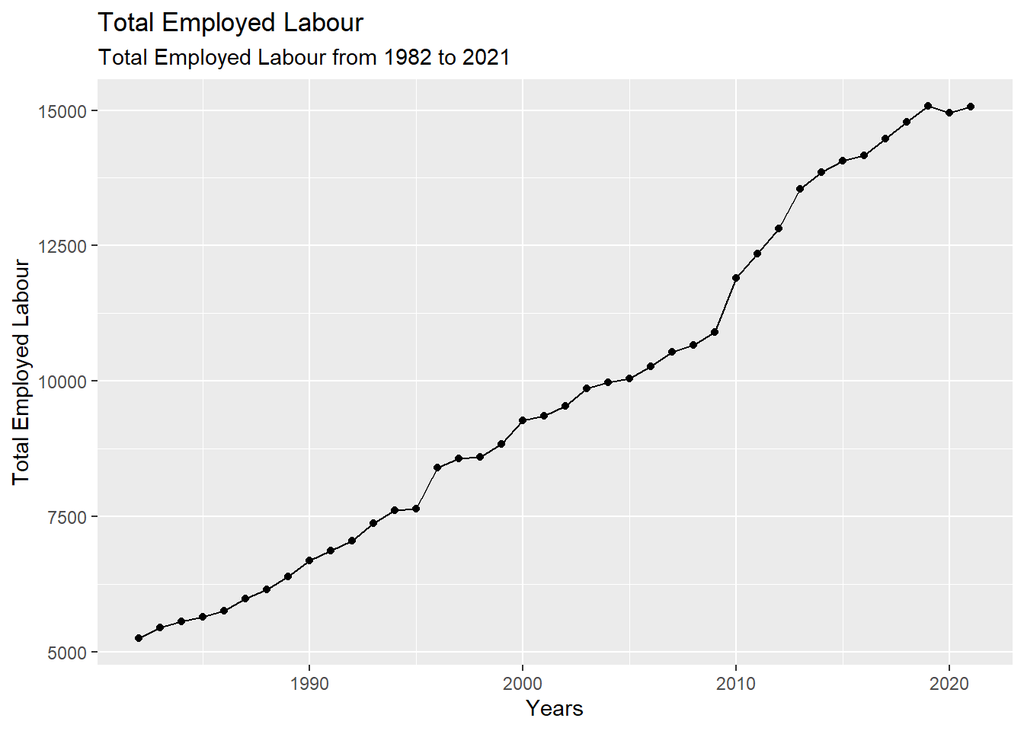

```r
# Total Employed Labour
ggplot(data = df["Employed_Male_thousands"] + df["Employed_Female_thousands"],
       mapping = aes(x = as.integer(df$Year),
                     y = Employed_Male_thousands)) +
        geom_point() +
        geom_line() +
        labs(title = "Total Employed Labour", subtitle = "Total Employed Labour from 1982 to 2021", x = "Years", y = "Total Employed Labour")
```

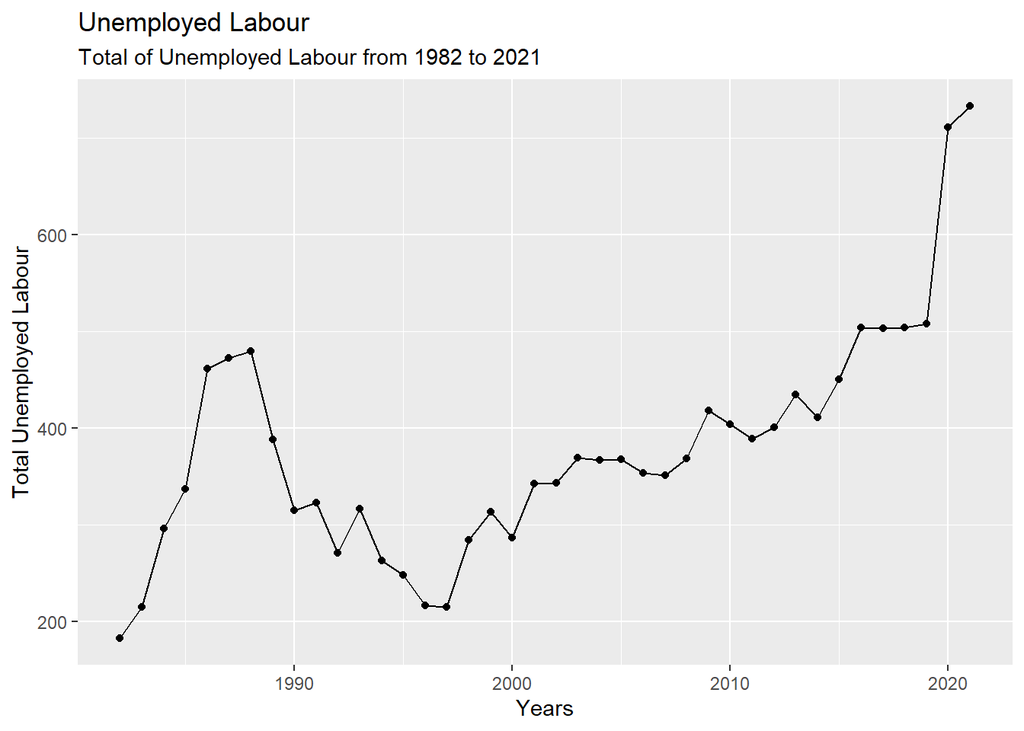

```r
# Total Umemployed Labour
ggplot(data = (df["Labour_Force_Male_thousands"] + df["Labour_Force_Female_thousands"])-(df["Employed_Male_thousands"] + df["Employed_Female_thousands"]),
       mapping = aes(x = as.integer(df$Year),
                     y = Labour_Force_Male_thousands)) +
        geom_point() +
        geom_line()+
        labs(title = "Unemployed Labour", subtitle = "Total of Unemployed Labour from 1982 to 2021", x = "Years", y = "Total Unemployed Labour")
```

[figure not shown]

```r
# Total Employed Labor by Group Age
ggplot(data = melt(data = cbind(Year = as.integer(df$Year), df) %>% select(c("Year", "Labour_Force_Age_15_to_59_thousands","Labour_Force_Age_60_to_64_thousands")), id.vars = "Year"),
       mapping = aes(x = Year,
                     y = value,
                     colour = variable,
                     group = variable)) +
        geom_point() +
        geom_line()+
        labs(title = "Total Employed Labor by Group Age", subtitle = "Total Employed Labour by Group Age from 1982 to 2021", x = "Years", y = "Total Unemployed Labour")
```

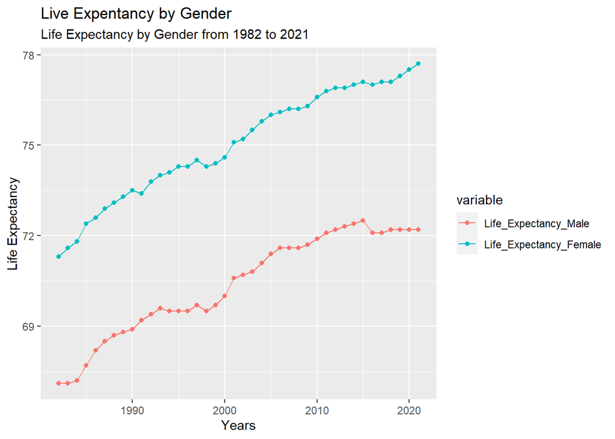

```r
# Live Expentancy by Gender
ggplot(data = melt(data = cbind(Year = as.integer(df$Year), df) %>% select(c("Year", "Life_Expectancy_Male", "Life_Expectancy_Female")), id.vars = "Year"),
       mapping = aes(x = Year,
                     y = value,
                     colour = variable,
                     group = variable)) +
        geom_point() +
        geom_line()+
        labs(title = "Live Expentancy by Gender", subtitle = "Life Expectancy by Gender from 1982 to 2021", x = "Years", y = "Life Expectancy")
```

```r
# Total Population VS Birth rate
Total_Population = df['Age_0_to_14_thousands'] + df['Labour_Force_Age_15_to_59_thousands'] + df['Labour_Force_Age_60_to_64_thousands'] + df['Age_above_65']
colnames(Total_Population) = "Total_Population"
cbind(Year = Total_Population/100, df)[c("Year" , "Total_Population", "Birth_Rate_percentage")]
```

```
##    Year Total_Population Birth_Rate_percentage
## 1  1982          116.821                  31.0
## 2  1983          120.339                  30.2
## 3  1984          123.558                  31.0
## 4  1985          126.456                  31.5
## 5  1986          130.367                  30.6
## 6  1987          134.357                  29.3
## 7  1988          137.754                  29.7
## 8  1989          140.719                  26.8
## 9  1990          144.336                  27.9
## 10 1991          147.754                  27.6
## 11 1992          150.643                  27.7
## 12 1993          156.210                  27.6
## 13 1994          159.653                  26.7
## 14 1995          161.271                  26.1
```

[output cut: 26 more lines]

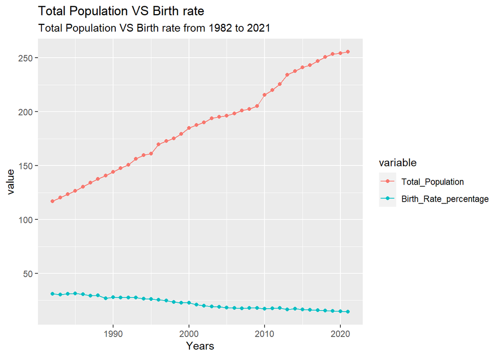

```r
#melt(cbind(Year = Total_Population/100, df)[c("Year" , "Total_Population", "Birth_Rate_percentage")], , id.vars = "Year")
ggplot(data = melt(cbind(Year = Total_Population/100, df)[c("Year" , "Total_Population", "Birth_Rate_percentage")], , id.vars = "Year"),
       mapping = aes(x = Year,
                     y = value,
                    colour = variable,
                     group = variable)) +
        geom_point() +
        geom_line()+
        labs(title = "Total Population VS Birth rate", subtitle = "Total Population VS Birth rate from 1982 to 2021", x = "Years")
```

```r
# Malaysia Population by Age Group
Population_by_Age_Group = df[c('Year', 'Age_0_to_14_thousands', 'Labour_Force_Age_15_to_59_thousands', 'Labour_Force_Age_60_to_64_thousands','Age_above_65')]
Population_by_Age_Group
```

```
##    Year Age_0_to_14_thousands Labour_Force_Age_15_to_59_thousands
## 1  1982                5723.7                              5290.9
## 2  1983                5818.8                              5515.9
## 3  1984                5933.9                              5711.6
## 4  1985                6081.2                              5847.3
## 5  1986                6223.5                              6075.5
## 6  1987                6370.0                              6301.8
## 7  1988                6512.0                              6478.5
## 8  1989                6650.0                              6624.8
## 9  1990                6775.0                              6833.0
## 10 1991                6899.9                              7036.0
## 11 1992                7038.6                              7147.9
## 12 1993                7192.0                              7538.5
## 13 1994                7329.2                              7706.3
## 14 1995                7453.3                              7717.7
```

[output cut: 67 more lines]

```r
ggplot(data = melt(Population_by_Age_Group, id.vars = "Year"),
       mapping = aes(x = Year,
                     y = value,
                    fill = variable)) +
        geom_area() +
        labs(title = "Malaysia Population by Age Group", subtitle = "Malaysia Population by Age Group from 1982 to 2021", x = "Years", y = "Total Population")
```

[figure not shown]

[figure not shown]